# Statistical inference with the GSS data

## Setup

### Load packages

```r
library(ggplot2)
library(dplyr)
library(statsr)
```

### Load data

Make sure your data and R Markdown files are in the same directory. When loaded your data file will be called `gss`. Delete this note when before you submit your work.

```r
load("gss.Rdata")
```

## Part 1: Data

Since, randomly sampled respondents took the survey, therefore, we can term the results as generalisable. Causality cannot be inferred due to no random assignment.

## Part 2: Research question

Does there appear to be a relationship between religious preference and working in military service? Minorities getting very low chances to serve in military can result in religious descrimination. Null Hypothesis: religious preference and working in military service are independent. Alternate Hypothesis: religious preference and working in military service are dependent.

## Part 3: Exploratory data analysis

```r
armed_proportion <- gss %>% filter(!is.na(vetyears)) %>%
  group_by(vetyears) %>%
  summarise(count=n())
armed_proportion
```

```
## # A tibble: 5 x 2
##   vetyears         count
##   <fct>            <int>
## 1 None             18093
## 2 Less Than 2 Yrs    816
## 3 2 To 4 Years      2123
## 4 More Than 4 Yrs    847
## 5 Some,Dk How Long     5
```

More than 50% of the population didn’t respond about working in military service. People serving in army for 2 to 4 years are high with 9.7 %, as compared to people working less than 2 years with 3.7 % and people working for more than 4 years with 3.8 %. Majority of the respondents didn’t serve the army with 82.6 %.

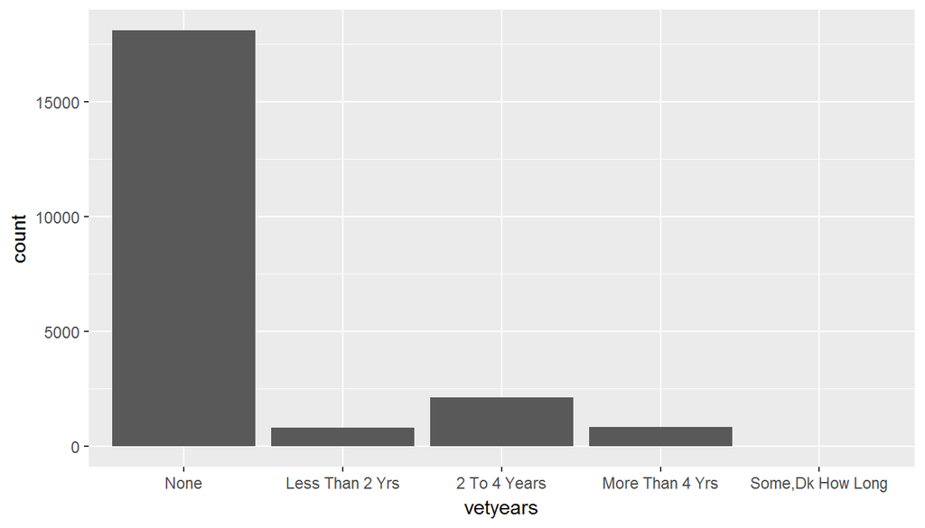

```r
armed_proportion <- armed_proportion %>% mutate(proportion = count/sum(count))
ggplot(data=armed_proportion,aes(x=vetyears,y=count)) + geom_bar(stat="identity")
```

```r
religion_proportion <- gss %>% filter(!is.na(relig)) %>%
  group_by(relig) %>%
  summarise(count=n())
religion_proportion <- religion_proportion %>% mutate(proportion = count/sum(count))
religion_proportion
```

```
## # A tibble: 13 x 3
##    relig                   count proportion
##    <fct>                   <int>      <dbl>
##  1 Protestant              33472   0.589
##  2 Catholic                13926   0.245
##  3 Jewish                   1155   0.0203
##  4 None                     6113   0.108
##  5 Other                     998   0.0176
##  6 Buddhism                  130   0.00229
##  7 Hinduism                   63   0.00111
##  8 Other Eastern              31   0.000546
##  9 Moslem/Islam              108   0.00190
## 10 Orthodox-Christian         96   0.00169
## 11 Christian                 588   0.0103
## 12 Native American            24   0.000422
## 13 Inter-Nondenominational   124   0.00218
```

The table of religious preferences reflects that Protestant is the largest religion to be preferred by the population with 59 % of the sample population. Catholic with 24.5 % and Jewish with 2 % are preferred next.

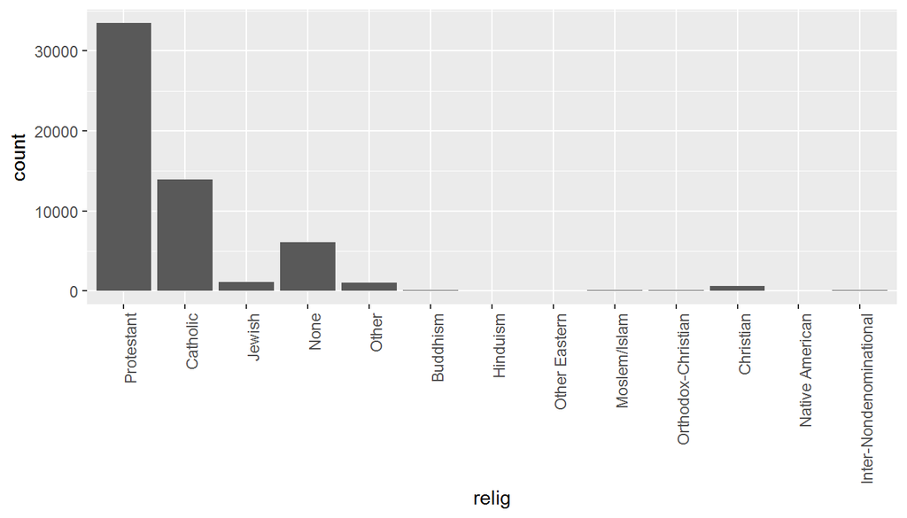

```r
ggplot(data=religion_proportion,aes(x=relig,y=count)) + geom_bar(stat="identity")+ theme(axis.text.x=element_text(angle=90, hjust=1))
```

```r
rel_vs_military <- table(gss$vetyears, gss$relig)
rel_vs_military
```

```
##
##                    Protestant Catholic Jewish  None Other Buddhism
##   None                  10922     4450    356  1745   275       21
##   Less Than 2 Yrs         522      186     16    67    13        0
##   2 To 4 Years           1286      546     48   198    26        3
##   More Than 4 Yrs         546      189     12    78    10        0
##   Some,Dk How Long          4        1      0     0     0        0
##
##                    Hinduism Other Eastern Moslem/Islam Orthodox-Christian
##   None                   13             7           21                 11
##   Less Than 2 Yrs         0             0            2                  2
##   2 To 4 Years            0             0            1                  1
##   More Than 4 Yrs         0             1            0                  0
##   Some,Dk How Long        0             0            0                  0
##
##                    Christian Native American Inter-Nondenominational
##   None                   190               8                      21
##   Less Than 2 Yrs          7               0                       0
##   2 To 4 Years             6               0                       0
##   More Than 4 Yrs          7               0                       1
##   Some,Dk How Long         0               0                       0
```

The table shows the count for each religion with respect to the time period spent working in military service. Some respondents never worked, some worked for a few time and some worked for more than 4 years. We can clearly see that minority religious individuals haven’t worked too much in military. Is it religious discrimination that stops the minorities to serve the American Army?

## Part 4: Inference

Since, we are working with 2 categorical variables with one atleast having more than 2 levels, therefore, a chi-squared independence test will be used. The observed counts are compared with the expected counts. Chi squared test along with degrees of freedom will be used to calculate p-value to conclude the relationship between two categorical variables.

The requirement for a chi-square test are as follows: 1.Independence: Since, USA is a large populated country and sample size is less than 10 % of the entire population, we can conclude that samples are independent due to random sampling without replacement.

2.Sample Size: Each particular cell must have atleast 5 expected cases which isn’t true here for all cells. Therefore, we will calculate p-value using simulation.

```r
chisq <- chisq.test(rel_vs_military)
round(chisq$expected, 1)
```

```
##
##                    Protestant Catholic Jewish   None Other Buddhism
##   None                10979.9   4441.6  357.2 1726.4 267.9     19.8
##   Less Than 2 Yrs       496.0    200.7   16.1   78.0  12.1      0.9
##   2 To 4 Years         1287.3    520.7   41.9  202.4  31.4      2.3
##   More Than 4 Yrs       513.7    207.8   16.7   80.8  12.5      0.9
##   Some,Dk How Long        3.0      1.2    0.1    0.5   0.1      0.0
##
##                    Hinduism Other Eastern Moslem/Islam Orthodox-Christian
##   None                 10.7           6.6         19.8               11.6
##   Less Than 2 Yrs       0.5           0.3          0.9                0.5
##   2 To 4 Years          1.3           0.8          2.3                1.4
##   More Than 4 Yrs       0.5           0.3          0.9                0.5
##   Some,Dk How Long      0.0           0.0          0.0                0.0
##
##                    Christian Native American Inter-Nondenominational
##   None                 173.6             6.6                    18.2
##   Less Than 2 Yrs        7.8             0.3                     0.8
##   2 To 4 Years          20.4             0.8                     2.1
##   More Than 4 Yrs        8.1             0.3                     0.9
##   Some,Dk How Long       0.0             0.0                     0.0
```

```r
chisq2 <- chisq.test(rel_vs_military, simulate.p.value= TRUE, B=100000)
round(rel_vs_military - chisq2$expected, 1)
```

```
##
##                    Protestant Catholic Jewish  None Other Buddhism
##   None                  -57.9      8.4   -1.2  18.6   7.1      1.2
##   Less Than 2 Yrs        26.0    -14.7   -0.1 -11.0   0.9     -0.9
##   2 To 4 Years           -1.3     25.3    6.1  -4.4  -5.4      0.7
##   More Than 4 Yrs        32.3    -18.8   -4.7  -2.8  -2.5     -0.9
##   Some,Dk How Long        1.0     -0.2   -0.1  -0.5  -0.1      0.0
##
##                    Hinduism Other Eastern Moslem/Islam Orthodox-Christian
##   None                  2.3           0.4          1.2               -0.6
##   Less Than 2 Yrs      -0.5          -0.3          1.1                1.5
##   2 To 4 Years         -1.3          -0.8         -1.3               -0.4
##   More Than 4 Yrs      -0.5           0.7         -0.9               -0.5
##   Some,Dk How Long      0.0           0.0          0.0                0.0
##
##                    Christian Native American Inter-Nondenominational
##   None                  16.4             1.4                     2.8
##   Less Than 2 Yrs       -0.8            -0.3                    -0.8
##   2 To 4 Years         -14.4            -0.8                    -2.1
##   More Than 4 Yrs       -1.1            -0.3                     0.1
##   Some,Dk How Long       0.0             0.0                     0.0
```

```r
chisq2$p.value
```

```
## [1] 0.2773572
```

Since, the p-value is greater than 0.05, therefore there is no association between religious preferance and working in military service. Hypothesis testing and confidence interval cannot be applied to this data set because we are dealing with more than 1 categorical variables with multiple levels.